# Nüfus ve Sosyal Araştırmalar Enstitüsü

# BOLUM 3: DEGERLENDIRME METRIKLERI (Evaluation Metrics)

## 3.1 Confusion Matrix (Karisiklik Matrisi)

Model bir tahmin yaptiginda dort sonuc mumkundur:

```
                     GERCEK DURUM
                   Pozitif    Negatif
               +-----------+-----------+
  TAHMIN Poz.  |    TP     |    FP     |  Model "pozitif" dedi
               | (Dogru +) | (Yanlis+) |
               +-----------+-----------+
         Neg.  |    FN     |    TN     |  Model "negatif" dedi
               | (Yanlis-) | (Dogru -) |
               +-----------+-----------+
```

| Kisaltma | Acilim | Anlami |
| --- | --- | --- |
| **TP** | True Positive | Pozitif, dogru tahmin edildi |
| **TN** | True Negative | Negatif, dogru tahmin edildi |
| **FP** | False Positive | Negatif ama pozitif dendi **(Tip I Hata)** |
| **FN** | False Negative | Pozitif ama negatif dendi **(Tip II Hata)** |

## 3.2 Dort Temel Metrik

**Accuracy** — Genel dogrluk orani: $$\text{Accuracy} = \frac{TP + TN}{TP + TN + FP + FN}$$

**Precision** — "Pozitif dedigimizin ne kadari gercekten pozitif?": $$\text{Precision} = \frac{TP}{TP + FP}$$

**Recall (Sensitivity)** — "Gercek pozitiflerin ne kadarini yakaladik?": $$\text{Recall} = \frac{TP}{TP + FN}$$

**F1-Score** — Precision ve Recall'un harmonik ortalamasi: $$\text{F1} = 2 \cdot \frac{\text{Precision} \times \text{Recall}}{\text{Precision} + \text{Recall}}$$

## 3.3 Hangi Metrigi Ne Zaman Kullanmali?

**Senaryo A — Kanser Taramasi:**  
FN (kanseri kacirmak) hayati tehdit eder! **Recall maksimize edilmeli.**  
Bedeli: Precision duser = daha fazla gereksiz biyopsi (FP artar ama kabul edilebilir)

**Senaryo B — Spam Filtresi:**  
FP (onemli maili spam'e gondermek) kabul edilemez. **Precision maksimize edilmeli.**  
Bedeli: Bazi spam'ler gelen kutusuna gecer (FN artar ama kabul edilebilir)

**Senaryo C — Dengeli onem:**  
Ikisi de onemli -> **F1-Score**. Ozellikle dengesiz veri setlerinde.

**Ekstra — Accuracy Paradoksu:**  
%99 negatif %1 pozitif olan bir veri setinde,  
"her seye negatif de" diyen model %99 accuracy alir!  
Ama hic bir pozitif yakalanamaz. Bu yuzden dengesiz veride F1 veya AUC-ROC tercih edilir.

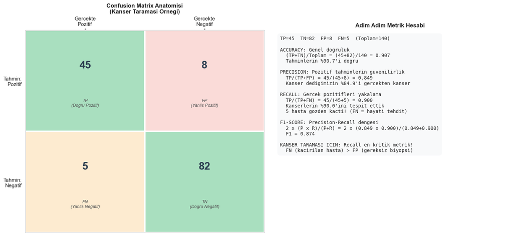

```python
import matplotlib.pyplot as plt

# ─── Metrikleri Adim Adim Gorsellestir ─────────────────────────────────────────

fig, (ax1, ax2) = plt.subplots(1, 2, figsize=(15, 7))

# Ornek degerler: kanser taramasi
TP, TN, FP, FN = 45, 82, 8, 5

# Sol: Confusion Matrix kutusu
matris = [[TP, FP], [FN, TN]]
renkler_m = [['#A9DFBF', '#FADBD8'], ['#FDEBD0', '#A9DFBF']]
etiketler_m = [['TP\n(Dogru Pozitif)', 'FP\n(Yanlis Pozitif)'],
               ['FN\n(Yanlis Negatif)', 'TN\n(Dogru Negatif)']]

for i in range(2):
    for j in range(2):
        ax1.add_patch(plt.Rectangle(
            (j, 1-i), 1, 1,
            facecolor=renkler_m[i][j], edgecolor='white', linewidth=3
        ))
        ax1.text(j+0.5, 1-i+0.65, str(matris[i][j]),
                 ha='center', va='center', fontsize=22, fontweight='bold', color='#2C3E50')
        ax1.text(j+0.5, 1-i+0.28, etiketler_m[i][j],
                 ha='center', va='center', fontsize=9, color='#555', style='italic')

ax1.set_xlim(0, 2); ax1.set_ylim(0, 2)
ax1.set_xticks([0.5, 1.5])
ax1.set_xticklabels(['Gercekte\nPozitif', 'Gercekte\nNegatif'], fontsize=11)
ax1.set_yticks([0.5, 1.5])
ax1.set_yticklabels(['Tahmin:\nNegatif', 'Tahmin:\nPozitif'], fontsize=11)
ax1.xaxis.set_label_position('top')
ax1.xaxis.tick_top()
ax1.set_title('Confusion Matrix Anatomisi\n(Kanser Taramasi Ornegi)', fontsize=12, fontweight='bold')

# Sag: Formul hesaplari
ax2.axis('off')
ax2.set_title('Adim Adim Metrik Hesabi', fontsize=12, fontweight='bold')

acc = (TP + TN) / (TP + TN + FP + FN)
pre = TP / (TP + FP)
rec = TP / (TP + FN)
f1  = 2 * pre * rec / (pre + rec)

hesap_metni = f"""TP={TP}  TN={TN}  FP={FP}  FN={FN}  (Toplam={TP+TN+FP+FN})

ACCURACY: Genel dogruluk
  (TP+TN)/Toplam = ({TP}+{TN})/{TP+TN+FP+FN} = {acc:.3f}
  Tahminlerin %{acc*100:.1f}'i dogru

PRECISION: Pozitif tahminlerin guvenilirlik
  TP/(TP+FP) = {TP}/({TP}+{FP}) = {pre:.3f}
  Kanser dedigimizin %{pre*100:.1f}'i gercekten kanser

RECALL: Gercek pozitifleri yakalama
  TP/(TP+FN) = {TP}/({TP}+{FN}) = {rec:.3f}
  Kanserlerin %{rec*100:.1f}'ini tespit ettik
  {FN} hasta gozden kacti! (FN = hayati tehdit)

F1-SCORE: Precision-Recall dengesi
  2 x (P x R)/(P+R) = 2 x ({pre:.3f} x {rec:.3f})/({pre:.3f}+{rec:.3f})
  F1 = {f1:.3f}

KANSER TARAMASI ICIN: Recall en kritik metrik!
  FN (kacirilan hasta) > FP (gereksiz biyopsi)"""

ax2.text(0.04, 0.97, hesap_metni, transform=ax2.transAxes,
         fontsize=10, verticalalignment='top', family='monospace',
         bbox=dict(boxstyle='round,pad=0.6', facecolor='#F8F9FA', alpha=0.95))

plt.tight_layout()
plt.savefig('metrikler_aciklama.png', dpi=120, bbox_inches='tight')
plt.show()
```

# BOLUM 4: KAPSAMLI MODEL KARSILASTIRMASI

## 4.1 Senaryo

Gogus kanseri veri setinde **GaussianNB, Decision Tree ve Random Forest** modellerini  
ayni kosullarda karsilastiriyoruz.

**Veri seti:** 30 medikal oznitelik (hucre sekli, boyutu, dokusu olcumleri)  
569 ornek: 212 malignant (kotu huylu), 357 benign (iyi huylu)

**Onemli not:** Veri seti dengesiz (%63 benign, %37 malignant).  
Bu yuzden sadece accuracy yeterli degil, recall ozellikle onemli!

**Makale baglantisi (Yahya et al., 2025):**  
Ayni karsilastirma Arapca haber metinlerinde yapildiginda:  
RandomForest %93 | XGBoost %92 | Gaussian NB %68  
Buyuk dil modelleri (BERT/GPT) bile geleneksel ML'in gerisinde kaldi!  
Neden? Bu gorevde feature engineering + siniflandirma odakli modeller  
jeneratif modellerden (T5, GPT) cok daha verimli.

```python
# ─── Veri Hazirligi (Veri Sizintisi Kontrolu) ────────────────────────────────
#
# Kritik Not: StandardScaler'i SADECE egitim setine fit etmek gerekir!
# Test setine fit edilirse, test bilgisi modele 'sizar' ve sonuclar yaniltici olur.
# Bu, makine ogrenmesindeki en yaygin hatalardan biridir.

kanser = load_breast_cancer()
Xk_tr, Xk_te, yk_tr, yk_te = train_test_split(
    kanser.data, kanser.target,
    test_size=0.2, random_state=42,
    stratify=kanser.target  # Sinif oranini koru
)
scaler = StandardScaler()
Xk_tr_s = scaler.fit_transform(Xk_tr)  # fit_transform: egitim verisinden ogrenip uygula
Xk_te_s  = scaler.transform(Xk_te)     # sadece transform: egitimden ogrenen parametrelerle uygula

print(f"Egitim seti : {Xk_tr_s.shape[0]} ornek")
print(f"Test seti   : {Xk_te_s.shape[0]} ornek")
print(f"Oznitelik   : {Xk_tr_s.shape[1]}")
print(f"Malignant   : {(yk_te==0).sum()} test ornegi")
print(f"Benign      : {(yk_te==1).sum()} test ornegi")
```

```
Egitim seti : 455 ornek
Test seti   : 114 ornek
Oznitelik   : 30
Malignant   : 42 test ornegi
Benign      : 72 test ornegi
```

```python
# ─── Modelleri Egit ve Karsilastir ───────────────────────────────────────────

modeller_k = {
    'GaussianNB':              GaussianNB(),
    'DecisionTree (depth=5)':  DecisionTreeClassifier(max_depth=5, random_state=42),
    'DecisionTree (budanmamis)': DecisionTreeClassifier(random_state=42),
    'RandomForest (100 agac)': RandomForestClassifier(n_estimators=100, random_state=42, n_jobs=1),
}

karsilastirma = {}
print("=== Model Egitimi ve Degerlendir ===")
print(f"{'Model':<30} {'Acc':>7} {'Prec':>7} {'Rec':>7} {'F1':>7}")
print("-" * 60)

for isim, model in modeller_k.items():
    model.fit(Xk_tr_s, yk_tr)
    y_p = model.predict(Xk_te_s)
    acc = accuracy_score(yk_te, y_p)
    pre = precision_score(yk_te, y_p)
    rec = recall_score(yk_te, y_p)
    f1  = f1_score(yk_te, y_p)
    karsilastirma[isim] = {'Accuracy': acc, 'Precision': pre, 'Recall': rec, 'F1': f1, 'y_p': y_p}
    isaretci = '  <- Overfitting?' if isim == 'DecisionTree (budanmamis)' else ''
    print(f"{isim:<30} {acc:>7.3f} {pre:>7.3f} {rec:>7.3f} {f1:>7.3f}{isaretci}")

print()
print("Gozlem 1: Budanmamis DT en dusuk recall -> kanser hastasi kaciriyor!")
print("Gozlem 2: RandomForest dengeli ve yuksek performans sagliyor.")
print("Gozlem 3: GaussianNB basit ama hizli bir baseline olarak kabul edilebilir.")
```

[output not shown]

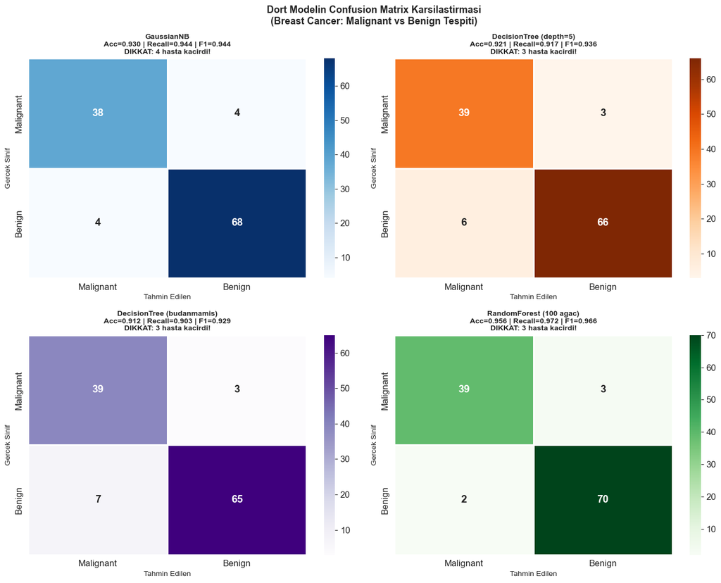

```python
# ─── Dort Confusion Matrix Yan Yana ─────────────────────────────────────────

fig, axes = plt.subplots(2, 2, figsize=(14, 11))
axes = axes.flatten()
cmaplar = ['Blues', 'Oranges', 'Purples', 'Greens']

for ax, (isim, sonuc), cmap in zip(axes, karsilastirma.items(), cmaplar):
    cm = confusion_matrix(yk_te, sonuc['y_p'])
    sns.heatmap(
        cm, annot=True, fmt='d', cmap=cmap, ax=ax,
        xticklabels=['Malignant', 'Benign'],
        yticklabels=['Malignant', 'Benign'],
        linewidths=1, linecolor='white',
        annot_kws={'size': 14, 'weight': 'bold'}
    )
    fn_val = cm[0][1]
    uyari  = f'DIKKAT: {fn_val} hasta kacirdi!' if fn_val > 2 else f'{fn_val} hasta kacti'
    ax.set_title(
        f'{isim}\nAcc={sonuc["Accuracy"]:.3f} | Recall={sonuc["Recall"]:.3f} | F1={sonuc["F1"]:.3f}\n{uyari}',
        fontsize=10, fontweight='bold'
    )
    ax.set_xlabel('Tahmin Edilen', fontsize=10)
    ax.set_ylabel('Gercek Sinif', fontsize=10)

plt.suptitle(
    'Dort Modelin Confusion Matrix Karsilastirmasi\n'
    '(Breast Cancer: Malignant vs Benign Tespiti)',
    fontsize=13, fontweight='bold'
)
plt.tight_layout()
plt.savefig('model_confusion_karsilastirma.png', dpi=110, bbox_inches='tight')
plt.show()
```

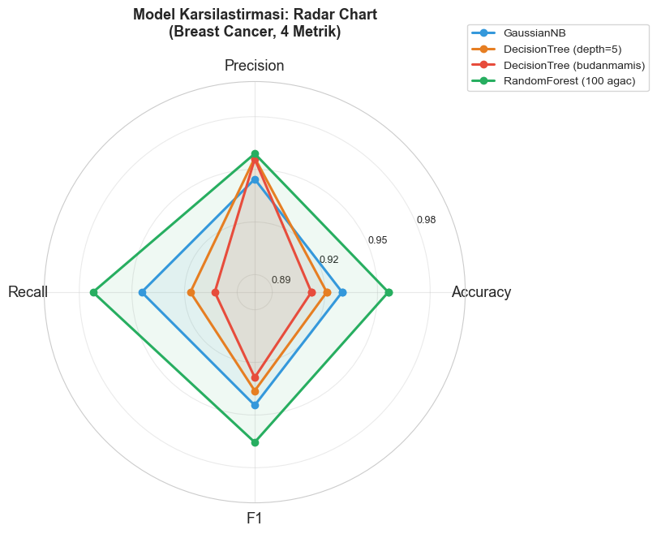

```
Radar chart okuma:
  Dis = Iyi, Ic = Kotu
  Genis alan = genel olarak daha iyi model
  Her eksen farkli bir metrik -> dengeli performans onemlidir
```

```python
# ─── Radar Chart: Dort Metrik Birlikte ───────────────────────────────────────
# Radar (Spider) chart ile 4 metrigi ayni anda gorsellestiriyoruz.
# Dis = Iyi, Ic = Kotu | Genis alan = Genel olarak daha iyi model

metrikler_r = ['Accuracy', 'Precision', 'Recall', 'F1']
n_m = len(metrikler_r)

# Acilar esit aralikli olarak olusturulur ve son = ilk ile kapatilir
acilar = np.linspace(0, 2 * np.pi, n_m, endpoint=False).tolist()
acilar += acilar[:1]

renk_map = {
    'GaussianNB':               '#3498DB',
    'DecisionTree (depth=5)':   '#E67E22',
    'DecisionTree (budanmamis)':'#E74C3C',
    'RandomForest (100 agac)':  '#27AE60',
}

fig, ax = plt.subplots(figsize=(9, 9), subplot_kw=dict(polar=True))

for isim, sonuc in karsilastirma.items():
    degerler  = [sonuc[m] for m in metrikler_r]
    degerler += degerler[:1]   # kapat

    ax.plot(acilar, degerler, 'o-', linewidth=2.2,
            label=isim, color=renk_map[isim])
    ax.fill(acilar, degerler, alpha=0.07, color=renk_map[isim])

ax.set_thetagrids(np.degrees(acilar[:-1]), metrikler_r, fontsize=13)
ax.set_ylim(0.88, 1.0)
ax.set_yticks([0.89, 0.92, 0.95, 0.98])
ax.set_yticklabels(['0.89', '0.92', '0.95', '0.98'], fontsize=9)
ax.set_title('Model Karsilastirmasi: Radar Chart\n(Breast Cancer, 4 Metrik)',
             fontsize=13, fontweight='bold', pad=20)
ax.legend(loc='upper right', bbox_to_anchor=(1.45, 1.15), fontsize=10)
ax.grid(True, alpha=0.4)

plt.tight_layout()
plt.savefig('model_radar.png', dpi=120, bbox_inches='tight')
plt.show()

print("Radar chart okuma:")
print("  Dis = Iyi, Ic = Kotu")
print("  Genis alan = genel olarak daha iyi model")
print("  Her eksen farkli bir metrik -> dengeli performans onemlidir")
```

# BOLUM 5: HIPERPARAMETRE OPTIMIZASYONU

## 5.1 GridSearchCV Nedir?

Bir modelin hiperparametrelerini "deneme yanilma" ile secmek  
hem zaman alir hem de overfitting'e yol acar.

**GridSearchCV su isi yapar:**

1. Belirtilen parametre izgarasindaki **tum kombinasyonlari** dener
2. Her kombinasyon icin **k-fold cross-validation** uygular
3. En yuksek CV skorunu veren parametreleri otomatik secer

**Cross-validation neden gerekli?**  
Test setini parametre seciminde kullanmak test setini "gorulmus" yapar.  
CV egitim verisi icinde bir "ic test" mekanizmasi olusturur, test seti bagimsiz kalir.

## 5.2 Random Forest Onemli Hiperparametreleri

| Parametre | Etkisi |
| --- | --- |
| `n_estimators` | Agac sayisi. Artinca daha kararli, daha yavas. |
| `max_depth` | Her agacin maksimum derinligi. Az = underfitting, Cok = overfitting. |
| `min_samples_split` | Bolmek icin gereken min ornek. Buyuk = daha basit agac. |
| `max_features` | Her bolmede denenen oznitelik sayisi. `sqrt` iyi baslangic. |

```python
# ─── GridSearchCV ile Random Forest Optimizasyonu ────────────────────────────
# DIKKAT: n_jobs=1 kullaniyoruz.
# GridSearchCV(n_jobs=-1) + RF(n_jobs=-1) = nested parallelism = hata!
# Guvenli: ya GridSearchCV ya da RF'de paralellizm aktif olmali.

parametre_izgarasi = {
    'n_estimators':      [50, 100, 200],
    'max_depth':         [None, 5, 10],
    'min_samples_split': [2, 5],
    'max_features':      ['sqrt', 'log2'],
}
# Toplam: 3 x 3 x 2 x 2 = 36 kombinasyon
# cv=5 fold: 36 x 5 = 180 model egitilecek

print("GridSearchCV baslatiyor... (36 kombinasyon x 5 fold = 180 fit)")
print("scoring='f1': Kanser tespitinde F1 daha anlamli\n")

grid_rf = GridSearchCV(
    estimator  = RandomForestClassifier(random_state=42),
    param_grid = parametre_izgarasi,
    cv         = 5,
    scoring    = 'f1',
    verbose    = 1,
    n_jobs     = 1
)
grid_rf.fit(Xk_tr_s, yk_tr)

print(f"\nEn iyi parametreler : {grid_rf.best_params_}")
print(f"En iyi CV F1 skoru  : {grid_rf.best_score_:.4f}")

y_opt = grid_rf.predict(Xk_te_s)
print(f"\nTest sonuclari (optimize edilmis model):")
print(f"  Accuracy  : {accuracy_score(yk_te, y_opt):.4f}")
print(f"  Precision : {precision_score(yk_te, y_opt):.4f}")
print(f"  Recall    : {recall_score(yk_te, y_opt):.4f}")
print(f"  F1-Score  : {f1_score(yk_te, y_opt):.4f}")
```

```
GridSearchCV baslatiyor... (36 kombinasyon x 5 fold = 180 fit)
scoring='f1': Kanser tespitinde F1 daha anlamli

Fitting 5 folds for each of 36 candidates, totalling 180 fits

En iyi parametreler : {'max_depth': None, 'max_features': 'sqrt', 'min_samples_split': 2, 'n_estimators': 200}
En iyi CV F1 skoru  : 0.9684

Test sonuclari (optimize edilmis model):
  Accuracy  : 0.9561
  Precision : 0.9589
  Recall    : 0.9722
  F1-Score  : 0.9655
```

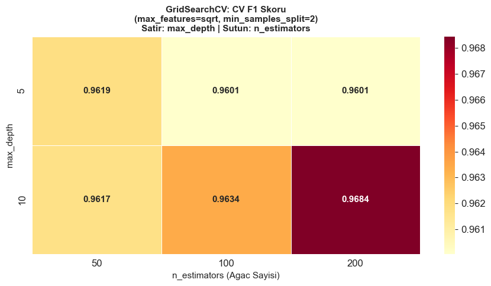

```
Isi haritasi okuma:
  Koyu renk = Yuksek F1 = Iyi kombinasyon
  Bu grafik parametre secimini transparan sekilde gosterir.
```

```python
# ─── GridSearch Sonuclarini Isi Haritasiyla Gorsellestir ─────────────────────
# Hangi parametre kombinasyonu en iyi skoru verdi?

import pandas as pd

sonuclar_df = pd.DataFrame(grid_rf.cv_results_)

# n_estimators x max_depth icin pivot tablo (max_features='sqrt', min_samples_split=2)
filtre = (
    (sonuclar_df['param_max_features'] == 'sqrt') &
    (sonuclar_df['param_min_samples_split'] == 2)
)
pivot = sonuclar_df[filtre].pivot_table(
    values='mean_test_score',
    index='param_max_depth',
    columns='param_n_estimators'
)

fig, ax = plt.subplots(figsize=(9, 5))
sns.heatmap(
    pivot, annot=True, fmt='.4f', cmap='YlOrRd', ax=ax,
    linewidths=0.5, annot_kws={'size': 11, 'weight': 'bold'}
)
ax.set_title(
    'GridSearchCV: CV F1 Skoru\n'
    '(max_features=sqrt, min_samples_split=2)\n'
    'Satir: max_depth | Sutun: n_estimators',
    fontsize=11, fontweight='bold'
)
ax.set_xlabel('n_estimators (Agac Sayisi)', fontsize=11)
ax.set_ylabel('max_depth', fontsize=11)

plt.tight_layout()
plt.savefig('gridsearch_heatmap.png', dpi=120, bbox_inches='tight')
plt.show()

print("Isi haritasi okuma:")
print("  Koyu renk = Yuksek F1 = Iyi kombinasyon")
print("  Bu grafik parametre secimini transparan sekilde gosterir.")
```

# DERS 8: TAM OZET

## Naive Bayes

**Bayes teoremini** kullanarak her sinibin olasiligini hesaplar, en yuksek olaslikli sinifi secer.

**Kilit kavramlar:**

- **Bag of Words** — Kelimeleri sayar, sira onemssiz
- **Laplace duzeltmesi** — Sifir olasiligi onler (count + 1)
- Prior x Likelihood = Posterior

**Ne zaman kullan?**

- Metin siniflandirma (spam, duygu analizi, haber kategorisi)
- Az veriyle hizli baseline model gerektiginde

**Zayif yonleri:**

- Kelime bagimsizilik varsayimi gercek dilde cogu zaman yanlis
- Sarkazm, negasyon, jargon yakalanamaz

## Karar Agaclari

**Ozyinelemeli Gini/Entropi minimizasyonuyla** "evet/hayir" bolmeleri yapar.

**Kilit kavramlar:**

- Gini = 0 tam saf dugum (iyi)
- max_depth overfitting kontrolu saglar
- Budama (pruning) ile overfitting onlenir

**Avantaj:** Yorumlanabilir — kurallar okunabilir  
**Dezavantaj:** Tek agac yuksek varyansa (overfitting'e) cok yatkin

## Random Forest

**Cok sayida karar agacini** Bagging + rastgele oznitelik secimi ile egitir.

**Kilit kavramlar:**

- Bootstrap ornekleme — Her agac farkli veri goruyor
- Rastgele oznitelik — Agaclar korelasyonsuz, hatalar iptal oluyor
- Feature Importance — Hangi oznitelik daha onemli?

**Ne zaman kullan?**

- Genel amacli siniflandirma ve regresyon
- Buyuk, gurultulu veri setlerinde
- Ilk deneme modeli olarak

## Degerlendirme Metrikleri

| Metrik | Formul | Ne Zaman? |
| --- | --- | --- |
| Accuracy | (TP+TN)/Toplam | Dengeli veri |
| Precision | TP/(TP+FP) | FP maliyetliyse (spam filtresi) |
| Recall | TP/(TP+FN) | FN maliyetliyse (kanser tespiti) |
| F1-Score | 2PR/(P+R) | Dengesiz veri, ikisi de onemli |

**Makale Baglantisi (Yahya et al., 2025 — ACL Workshop):**  
Arapca haber metinlerinde bias tespiti: RandomForest %93, XGBoost %92, GaussianNB %68  
Buyuk dil modelleri (AraBERT %58, T5 %15) geleneksel ML'in gerisinde kaldi.  
DERS: Her problem icin en karmasik model, en iyi model degildir!

- Not: Şebnem Paluluoğlu — Veri Analizi Okulu, Boğaziçi Üniversitesi*  
  *Akademik referans: Yahya M. et al. (2025). Bias Detection in Media. ACL Workshop on Nakba Narratives.*

-Memreu